# Part 2

2026-04-03

```r
library(readr)
library(dplyr)
```

```r
library(ggplot2)
library(tidyr)
data = read_csv("nhanes.csv")
names(data)
```

```
##  [1] "id"                 "age"                "sex"
##  [4] "race"               "income_to_poverty"  "education"
##  [7] "marriage"           "household_size"     "bmi"
## [10] "is_obese"           "fiber_den"          "sugar_den"
## [13] "satfat_den"         "sodium_den"         "kcal"
## [16] "protein_intake"     "carb_intake"        "fiber_intake"
## [19] "sugar_intake"       "fat_intake"         "sodium_intake"
## [22] "cant_afford_meals"  "food_security"      "health_condition"
## [25] "health_location"    "seen_mental_health"
```

```r
head(data, 2)
```

```
## # A tibble: 2 × 26
##       id   age sex   race    income_to_poverty education marriage household_size
##    <dbl> <dbl> <chr> <chr>               <dbl> <chr>     <chr>             <dbl>
## 1 130378    43 Male  Non-Hi…                 5 College … Married…              4
## 2 130379    66 Male  Non-Hi…                 5 College … Married…              2
## # ℹ 18 more variables: bmi <dbl>, is_obese <dbl>, fiber_den <dbl>,
## #   sugar_den <dbl>, satfat_den <dbl>, sodium_den <dbl>, kcal <dbl>,
## #   protein_intake <dbl>, carb_intake <dbl>, fiber_intake <dbl>,
## #   sugar_intake <dbl>, fat_intake <dbl>, sodium_intake <dbl>,
## #   cant_afford_meals <chr>, food_security <chr>, health_condition <chr>,
## #   health_location <chr>, seen_mental_health <chr>
```

# Part 2

### Looking at obesity

Since we are observing obesity from the NHANES dataset, we are looking at a binary variable: whether a patient is obese or not. Thus, we expect a binomial distribution in the form of X ~ Binomial(n, p), where n is the sample size and p is the probability of being obese. As such, n can be determined by taking the number of rows of the dataset, and p can be determined by taking the number of people classified as obese over the total rows.

Additionally, we can calculate the mean via the equation n * p, and standard deviation with sqrt(n * p * (1-p)).

```r
binomial_n = nrow(data)
binomial_p = sum(data$is_obese) / binomial_n
binomial_mean = binomial_n * binomial_p
binomial_std = sqrt(binomial_n * binomial_p * (1-binomial_p))
binomial_parameters = c(binomial_n, binomial_p, binomial_mean, binomial_std)

binomial_parameters
```

```
## [1] 3787.0000000    0.4298917 1628.0000000   30.4653287
```

So the distribution for our obesity data from the NHANES 2021-23 dataset can be represented as Binomial(3787, 0.43).

With a binomial distribution, we would be able to estimate the probability of a specific number of “successes”, in this case being obese. To do so, we could take a large number of samples with replacement to generate a distribution of probabilities. First we define the function to do so…

```r
#bootstrap time
bootstrapper = function(n, dataset) {
  #N is the number of bootstrap samples to take
  #DATASET is the dataframe to pass in
  return_vect = c(rep(0, n))
  sample_length = nrow(dataset)
  for (i in c(1:n)) {
    this_sample = dataset |>
      sample_n(sample_length, replace=TRUE)
    return_vect[i] = mean(this_sample$is_obese)
  }
  return(return_vect)
  #returns a vector of length N of probabilities of successes
}
```

Then we generate 10,000 samples and store it to a vector.

```r
p_samples = bootstrapper(10000, data) #very slow!!!
```

Now we can see what it looks like.

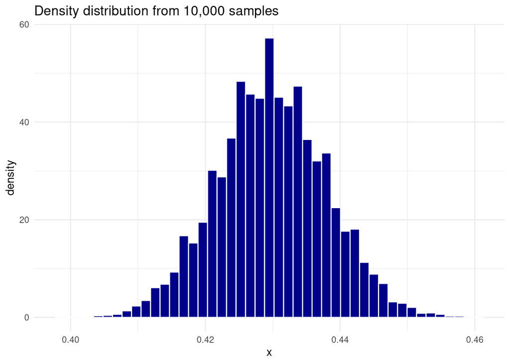

```r
ggplot(data.frame(x=p_samples), aes(x=x)) +
  geom_histogram(aes(y=after_stat(density)), bins=45, fill="darkblue", color="white") +
  labs(title="Density distribution from 10,000 samples") +
  theme_minimal()
```

Now that we have an empirical dataset for the distribution, we can calculate probabilities. For example, we can find the probability that the proportion of obese individuals in a sample exceeds 45%.

```r
#for > 45%:
numerator = sum(p_samples > 0.45)
denominator = length(p_samples)

prob_more_45 = numerator / denominator
prob_more_45
```

```
## [1] 0.007
```

Using ggplot2, we can visualize what this might look like:

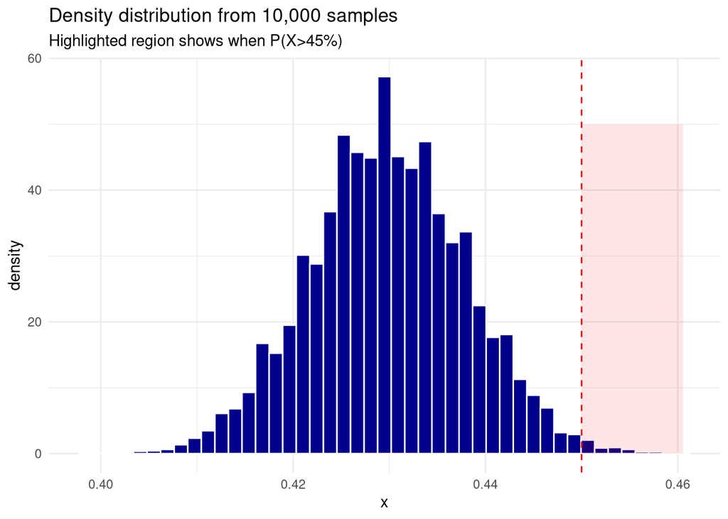

```r
ggplot(data.frame(x=p_samples), aes(x=x)) +
  geom_histogram(aes(y=after_stat(density)), bins=45, fill="darkblue", color="white") +
  geom_vline(xintercept = 0.45, color="red", linetype="dashed") +
  annotate("rect", xmin = 0.45, xmax = max(p_samples), ymin = 0, ymax = 50, alpha = 0.1, fill = "red") +
  labs(title="Density distribution from 10,000 samples", subtitle="Highlighted region shows when P(X>45%)") +
  theme_minimal()
```

And additionally, we can compare our bootstrap-calculated probability to that of R’s builtin binomial distributions.

```r
prob_more_45_r = pbinom(0.45*binomial_parameters[[1]], size=binomial_parameters[[1]], prob=binomial_parameters[[2]], lower.tail=FALSE)
print(paste0("Manually calculated probability: ", round(prob_more_45, 5), " || pbinom calculated probability: ", round(prob_more_45_r, 5)))
```

```
## [1] "Manually calculated probability: 0.007 || pbinom calculated probability: 0.00608"
```

Additionally, since our sample size is large, the distribution of the proportions approaches normality, as dictated by the Central Limit Theorem. We can confirm this with a QQ Plot.

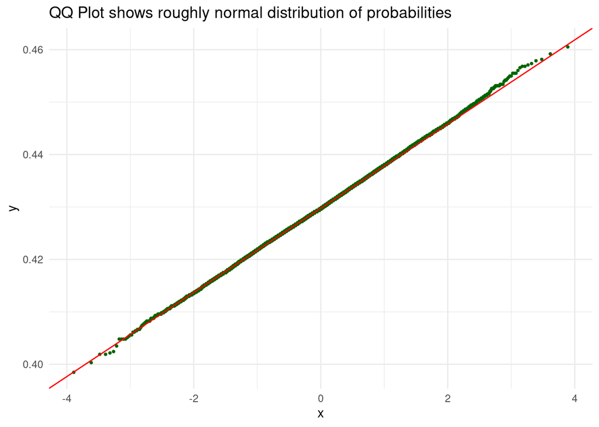

```r
ggplot(data.frame(x=p_samples), aes(sample=x)) +
  geom_qq(color="darkgreen", size=0.7) +
  geom_qq_line(color="red") +
  labs(title="QQ Plot shows roughly normal distribution of probabilities") +
  theme_minimal()
```